# 12. Multivariate Distance Using Bray Curtis

Author

Colin J Lee

We want to calculate the multivariate distance between two profiles, between and within-person. Bray-Curtis dissimilarity is an absolute distance metric, like Euclidian and Manhattan, but it can be decomposed into replacement (variables in one profile are higher *and* lower than another profile) and nestedness (one profile’s variables are uniformly higher or lower than another profile). At the between-level: we want to calculate the Bray-Curtis dissimilarity between a profile and the mean of the sample’s aggregate profiles. i think? Within p: 1. B-C between a profile’s means and the mean of the participant’s time series 2. B-C between one profile’s means and another profile’s means (obv within person)

Between person: 1. distance matrix of profile means 2. a profile’s means and sample profile mean

within-person: 1. a profile’s mean and time series mean 2. a profile’s mean and another profile’s mean

typology: 1. profile mean and typology

```r
library(psych)
library(cowplot)
library(betapart)
library(kableExtra)
library(tidyverse)
```

```
✖ ggplot2::%+%()      masks psych::%+%()
```

```r
set.seed(420)
wd <- getwd()
setwd(wd)

#load prepped data
load(sprintf("%s/Data/mc.RData", wd)) #between person facet means
load(sprintf("%s/Data/pp_wide_sit.RData", wd))
load(sprintf("%s/Data/pp_nested_profiles.RData", wd)) #calc profile level facet means
load(sprintf("%s/Data/pp_nested_pre_LPA.RData", wd)) #to calculate participant level facet means



#pers state only in data of pp_nested_profiles
pp_nested_profiles <- pp_nested_profiles %>%
  mutate(data = map(data, function(x) x %>% select(Sociability:CrtvImagination)))

pp_nested_pre_LPA <- pp_nested_pre_LPA %>%
  mutate(data = map(data, function(x) x %>% select(Sociability:CrtvImagination)))

# Download and source BrayCurtisDissimilarity_Calculate.R
# https://github.com/taktsun/dissimilarity-for-ESM-data
# source("https://github.com/taktsun/dissimilarity-for-ESM-data/raw/main/BrayCurtisDissimilarity_Calculate.R")

#colors for the density distributions
gg_color_hue <- function(n) {
  hues = seq(15, 375, length = n + 1)
  hcl(h = hues, l = 65, c = 100)[1:n]
}
```

Data I need: Mean vector of profiles Mean vector of sample DF with the mean vector as the first observation

```r
#sample mean
pp_sample_mean <- describe(pp_wide_sit %>% select(Sociability:CrtvImagination)) %>%
  select(mean)

pp_nested_profiles <- pp_nested_profiles %>%
  mutate(sample_mean = rep(pp_sample_mean, nrow(pp_nested_profiles)))


#profile means
pp_nested_profiles <- pp_nested_profiles %>%
  mutate(profile_mean = map(data, colMeans)) #profile means

#person means
pp_nested_pre_LPA <- pp_nested_pre_LPA %>%
  mutate(person_mean = map(data, colMeans))

#add person_means to nested_profile df
pp_nested_pre_LPA <- pp_nested_pre_LPA %>% select(-data)
pp_nested_profiles <- pp_nested_profiles %>% left_join(pp_nested_pre_LPA)
#insert person mean as first row of dataframe
pp_nested_profiles <- pp_nested_profiles %>%
  mutate(prof_to_person = map2(person_mean, data, function(x, y) bind_rows(x = x, y = y)))

#i do typology data prep below in typology section
```

Typologies in a separate df 3 Typologies from Merz and Roesch. Taken from table 2

```r
# they are in NEOAC order; also, reverse scoring neurocitism
well_adj_vec <- c((6 - 2.38), 3.6, 3.78, 4.19, 3.72)
reserved_vec <- c((6 - 3.21), 2.65, 3.23, 3.6, 3.29)
excitable_vec <- c((6 - 3.69), 3.74, 3.84, 4.10, 3.5)

#EACNO order
index <- c(2,4,5,1,3)
well_adj_vec <- well_adj_vec[index]
reserved_vec <- reserved_vec[index]
excitable_vec <- excitable_vec[index]

#POMP
pomp <- function(x, min, max){
  (x - min)/(max - min)*100
}

reserved_vec <- pomp(x = reserved_vec, min = 1, max = 5)
names(reserved_vec) <- c("Extraversion", "Agreeableness", "Conscientiousness", "Neuroticism_r", "Openness")
well_adj_vec <- pomp(x = well_adj_vec, min = 1, max = 5)
names(well_adj_vec) <- c("Extraversion", "Agreeableness", "Conscientiousness", "Neuroticism_r", "Openness")
excitable_vec <- pomp(x = excitable_vec, min = 1 , max = 5)
names(excitable_vec) <- c("Extraversion", "Agreeableness", "Conscientiousness", "Neuroticism_r", "Openness")

# #make them lists for mapping
reserved_list <- rep(list(reserved_vec), nrow(pp_nested_profiles))
well_adj_list <- rep(list(well_adj_vec), nrow(pp_nested_profiles))
excitable_list <- rep(list(excitable_vec), nrow(pp_nested_profiles))
```

## now we can do analyses

1. Between-person
2. mean profile - mean profile across sample

```r
#total number of comparisons
(191*(191-1))/2
```

```
[1] 18145
```

```r
#matrix of profile means
mc_prof_prof_dist <- mc %>%
  select(Sociability:CrtvImagination) %>% #facets only
  as.matrix

prof_prof_bray <- bray.part(mc_prof_prof_dist) #lower tri mat; doesnt include diagonal
save(prof_prof_bray, file = "Data/prof_prof_bray.RData")

#make it a df to make comparisons between repl and nest
prof_prof_btwn_bray <- data.frame(
  SID = mc$SID,
  Profiles = mc$Profiles,
  bray = prof_prof_bray[["bray"]],
  repl = prof_prof_bray[["bray.bal"]],
  nest = prof_prof_bray[["bray.gra"]]
)

save(prof_prof_btwn_bray, file = "Data/prof_prof_btwn_bray.RData")

#what proportion is repl>nest
table(prof_prof_btwn_bray$repl > prof_prof_btwn_bray$nest)
```

```
FALSE  TRUE
12098  6047
```

```r
6047/18145 #pps
```

```
[1] 0.3332599
```

```r
8374/33930 #ipcs
```

```
[1] 0.2468022
```

```r
14421/52075 #total
```

```
[1] 0.2769275
```

```r
#descriptives of each
describe(prof_prof_btwn_bray$bray) %>% select(mean, sd, median, min, max)
```

|  | mean | sd | median | min | max |
| --- | --- | --- | --- | --- | --- |
| X1 | 0.1084301 | 0.06274942 | 0.09984292 | 0.004354726 | 0.495776 |

```r
describe(prof_prof_btwn_bray$repl) %>% select(mean, sd, median, min, max)
```

|  | mean | sd | median | min | max |
| --- | --- | --- | --- | --- | --- |
| X1 | 0.03107064 | 0.03181859 | 0.02137274 | 0 | 0.2139979 |

```r
describe(prof_prof_btwn_bray$nest) %>% select(mean, sd, median, min, max)
```

|  | mean | sd | median | min | max |
| --- | --- | --- | --- | --- | --- |
| X1 | 0.07735941 | 0.06834693 | 0.05869244 | 2.022892e-06 | 0.495776 |

```r
#ipcs
load("~/Downloads/Projects/Trait Profiles IPCS Dataset/Data/prof_prof_bray_ipcs.RData")
pps_prof_prof <- prof_prof_bray[["bray"]]
pp_prof_prof <- prof_prof_bray_ipcs[["bray"]]
describe(pp_prof_prof)
```

|  | vars | n | mean | sd | median | trimmed | mad | min | max | range | skew | kurtosis | se |
| --- | --- | --- | --- | --- | --- | --- | --- | --- | --- | --- | --- | --- | --- |
| X1 | 1 | 33930 | 0.1269586 | 0.06556901 | 0.1114142 | 0.1188902 | 0.0564536 | 0.01518439 | 0.5368707 | 0.5216863 | 1.269379 | 2.05944 | 0.0003559645 |

```r
prof_prof_btwn_both_df <- data.frame(sample = c(rep("PPS", length(pps_prof_prof)),
                              rep("IPCS", length(pp_prof_prof))),
                 value=c(pps_prof_prof, pp_prof_prof))

prof_prof_btwn_plot <- ggplot(prof_prof_btwn_both_df, aes(x=value, fill=sample))+
  geom_density(alpha = 0.5) +
  scale_colour_manual(values=c(gg_color_hue(2))) +
  ggtitle("Between-Person Profile to Profile") +
  xlab("Bray-Curtis Dissimilarity Index") +
  ylab("Density") +
  theme_bw(base_size = 8)

save(prof_prof_btwn_plot, file = "Data/prof_prof_btwn_plot.RData")
```

2. mean profile - sample mean

```r
#matrix of profile means and sample mean
mc_prof_sample_dist <- bind_rows(colMeans(pp_wide_sit %>% select(Sociability:CrtvImagination)),
                                 mc %>% select(Sociability:CrtvImagination)) %>%
  as.matrix()

prof_sample_bray <- bray.part(mc_prof_sample_dist) #lower tri mat
#only first column (sample compared with each profile)
prof_sample_bray_vector <- prof_sample_bray[["bray"]][1:nrow(pp_nested_profiles)] # the distance between the sample mean and the other 191 profiles; 1 as an index because bray.part output excludes the [1,1] position
save(prof_sample_bray_vector, file = "Data/prof_sample_bray_vector.RData")

#make it a df to make comparisons between repl and nest
prof_sample_btwn_bray <- data.frame(
  SID = mc$SID,
  Profiles = mc$Profiles,
  bray = prof_sample_bray[["bray"]][1:nrow(pp_nested_profiles)],
  repl = prof_sample_bray[["bray.bal"]][1:nrow(pp_nested_profiles)],
  nest = prof_sample_bray[["bray.gra"]][1:nrow(pp_nested_profiles)]
)

save(prof_sample_btwn_bray, file = "Data/prof_sample_btwn_bray.RData")
#what proportion is repl>nest
table(prof_sample_btwn_bray$repl > prof_sample_btwn_bray$nest)
```

```
FALSE  TRUE
  146    45
```

```r
45/146 #pps
```

```
[1] 0.3082192
```

```r
56/261 #ipcs
```

```
[1] 0.2145594
```

```r
101/407
```

```
[1] 0.2481572
```

```r
#sample level descriptives of decomposed bray (full, repl, nest)
describe(prof_sample_bray[["bray"]][1:nrow(pp_nested_profiles)]) #full
```

|  | vars | n | mean | sd | median | trimmed | mad | min | max | range | skew | kurtosis | se |
| --- | --- | --- | --- | --- | --- | --- | --- | --- | --- | --- | --- | --- | --- |
| X1 | 1 | 191 | 0.07643184 | 0.04509394 | 0.06230221 | 0.06927667 | 0.02723726 | 0.02027613 | 0.2696797 | 0.2494036 | 1.98635 | 4.844138 | 0.003262883 |

```r
describe(prof_sample_bray[["bray.bal"]][1:nrow(pp_nested_profiles)]) #repl
```

|  | vars | n | mean | sd | median | trimmed | mad | min | max | range | skew | kurtosis | se |
| --- | --- | --- | --- | --- | --- | --- | --- | --- | --- | --- | --- | --- | --- |
| X1 | 1 | 191 | 0.01905612 | 0.02439276 | 0.009125974 | 0.01441965 | 0.01323423 | 0 | 0.1470697 | 0.1470697 | 2.253295 | 6.823661 | 0.001764998 |

```r
describe(prof_sample_bray[["bray.gra"]][1:nrow(pp_nested_profiles)]) #nest
```

|  | vars | n | mean | sd | median | trimmed | mad | min | max | range | skew | kurtosis | se |
| --- | --- | --- | --- | --- | --- | --- | --- | --- | --- | --- | --- | --- | --- |
| X1 | 1 | 191 | 0.05737573 | 0.04681568 | 0.04819329 | 0.05061536 | 0.03147966 | 0.0007766025 | 0.2693574 | 0.2685808 | 1.977634 | 5.365648 | 0.003387464 |

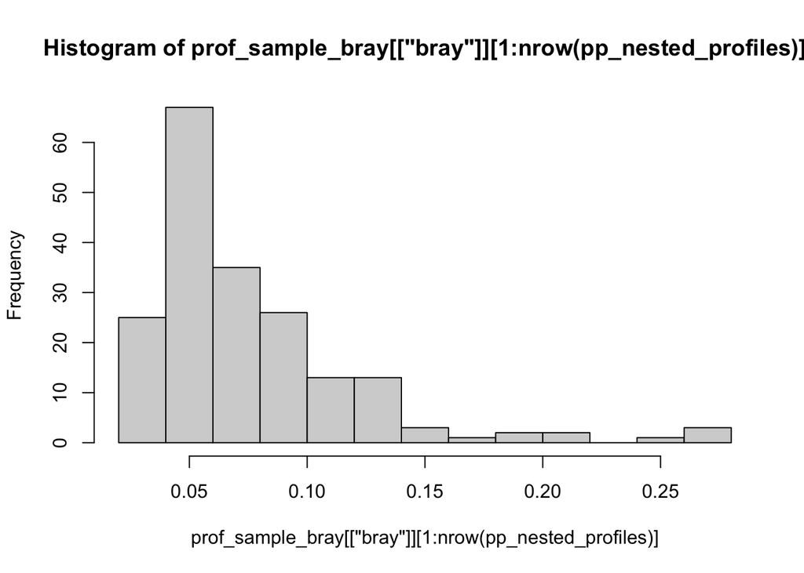

```r
hist(prof_sample_bray[["bray"]][1:nrow(pp_nested_profiles)])
```

```r
which.min(prof_sample_bray[["bray"]][1:nrow(pp_nested_profiles)])
```

```
[1] 45
```

```r
prof_sample_dist_pp <- prof_sample_bray[["bray"]][1:nrow(pp_nested_profiles)] %>% as.data.frame
colnames(prof_sample_dist_pp) <- "dist"

#ipcs
load("~/Downloads/Projects/Trait Profiles IPCS Dataset/Data/prof_sample_dist_ipcs.RData")

prof_sample_both_df <- data.frame(sample = c(rep("PPS", length(prof_sample_dist_pp)),
                              rep("IPCS", length(prof_sample_dist_ipcs))),
                 value=c(prof_sample_dist_pp$dist, prof_sample_dist_ipcs$dist))

prof_sample_dist_plot <- ggplot(prof_sample_both_df, aes(x=value, fill=sample))+
    geom_density(alpha = 0.5) +
  scale_colour_manual(values=c(gg_color_hue(2))) +
  ggtitle("Profile Mean to Sample Mean") +
  xlab("Bray-Curtis Dissimilarity Index") +
  ylab("Density") +
  theme_bw(base_size = 8)
save(prof_sample_dist_plot, file = "Data/prof_sample_dist_plot.RData")
```

plot least and most similar

```r
#pp sample mean to plot
pp_sample_mean_plot <- describe(pp_wide_sit %>% select(Sociability:CrtvImagination)) %>%
  select(mean)
pp_sample_mean_plot$facet <- rownames(pp_sample_mean_plot)
pp_sample_mean_plot$facet <- factor(pp_sample_mean_plot$facet, levels = c("Sociability", "EnergyLevel", "Assertive", "Trust", "Respect", "Compassion", "Productivity", "Responsibility", "Organization", "Depression_r", "Anxiety_r", "EmotionalVol_r", "IntCuriosity", "AesthSense", "CrtvImagination"))
pp_sample_mean_plot <- pp_sample_mean_plot %>% rename(value = mean) %>% mutate(Profiles = "Sample Mean")

#max dist
max_index <- which.max(prof_sample_bray[["bray"]][1:nrow(pp_nested_profiles)]) #183
prof_sample_bray[["bray"]][max_index]
```

```
[1] 0.2696797
```

```r
prof_to_sample_max <- mc %>% filter(SID == pp_nested_profiles[max_index,]$SID & Profiles == pp_nested_profiles[max_index,]$Profiles) %>%
  select(Sociability:CrtvImagination) %>%
  t() %>%
  as.data.frame()

prof_to_sample_max$facet <- rownames(prof_to_sample_max)
prof_to_sample_max$facet <- factor(prof_to_sample_max$facet, levels = c("Sociability", "EnergyLevel", "Assertive", "Trust", "Respect", "Compassion", "Productivity", "Responsibility", "Organization", "Depression_r", "Anxiety_r", "EmotionalVol_r", "IntCuriosity", "AesthSense", "CrtvImagination"))
prof_to_sample_max <- prof_to_sample_max %>% rename(value = V1) %>% mutate(Profiles = paste0("Max Distance (", round(prof_sample_bray[["bray"]][max_index],2), ")" ))
prof_to_sample_max <- bind_rows(prof_to_sample_max, pp_sample_mean_plot)

#min
min_index <- which.min(prof_sample_bray[["bray"]][1:nrow(pp_nested_profiles)])#45

prof_to_sample_min <- mc %>% filter(SID == pp_nested_profiles[min_index,]$SID & Profiles == pp_nested_profiles[min_index,]$Profiles) %>%
  select(Sociability:CrtvImagination) %>%
  t() %>%
  as.data.frame()

prof_to_sample_min$facet <- rownames(prof_to_sample_min)
prof_to_sample_min$facet <- factor(prof_to_sample_min$facet, levels = c("Sociability", "EnergyLevel", "Assertive", "Trust", "Respect", "Compassion", "Productivity", "Responsibility", "Organization", "Depression_r", "Anxiety_r", "EmotionalVol_r", "IntCuriosity", "AesthSense", "CrtvImagination"))
prof_to_sample_max_min <- bind_rows(prof_to_sample_max, prof_to_sample_min %>% rename(value = V1) %>% mutate(Profiles = paste0("Min Distance (", round(prof_sample_bray[["bray"]][min_index],2), ")")))

profile_plot_fnc <- function(df){
  df %>%
    ggplot(aes(x = facet, y = value, group = Profiles, color = Profiles)) +
    geom_line(linewidth = 1.25) +
    geom_point(size = 2.25, color = "black") +
    labs(x = NULL, y = "Self-Reported Score (POMP)") +
    ylim(0,103) +
    theme_bw(base_size = 8) +
    theme(axis.text.x = element_text(angle = 45, hjust = 1, size = 10), legend.position = "top") +
    labs(title = "Profiles With Maximum and Minimum Distances from PPS Facet Means") +
    #annotate("rect", xmin = 3.8, xmax = 6.2, ymin = 46, ymax = 93, fill = "green", alpha = .2) +
    #annotate("rect", xmin = 0.8, xmax = 3.2, ymin = 25, ymax = 77, fill = "red", alpha = .2) +
    geom_vline(xintercept = c(3.5, 6.5, 9.5, 12.5), size = 0.25, alpha = 0.8) +
    annotate("text", x = 2, y = 102, size = 2.5,label = "Extraversion") +
    annotate("text", x = 5, y = 102, size = 2.5,label = "Agreeableness") +
    annotate("text", x = 8, y = 102, size=  2.5, label = "Conscientiousness") +
    annotate("text", x = 11, y = 102, size = 2.5, label = "Emotional Stability") +
    annotate("text", x = 14, y = 102, size = 2.5, label = "Openness")
}


pdf(file = "z.Plots/Profile Comparisons/Min Max BCD Plot.pdf")
profile_plot_fnc(prof_to_sample_max_min)
dev.off()
```

4. within
1. profile obs-person mean

```r
pp_nested_profiles_multi <- pp_nested_profiles %>%
  group_by(SID) %>%
  filter(length(unique(Profiles)) > 1) %>% #>1 profile only for within person analyses
  ungroup() %>%
  mutate(prof_person_dist = map(prof_to_person, function(x) bray.part(x))) #1 BCD value, decomposed into replacement and nestedness

#overall bray
prof_person_bray <- list()
for(i in 1:nrow(pp_nested_profiles_multi)){
    prof_person_bray[[i]] <- pp_nested_profiles_multi$prof_person_dist[[i]]$bray[1:pp_nested_profiles_multi$nrows[[i]]] #first col
}

#repl bray
prof_person_bray_repl <- list()
for(i in 1:nrow(pp_nested_profiles_multi)){
    prof_person_bray_repl[[i]] <- pp_nested_profiles_multi$prof_person_dist[[i]]$bray.bal[1:pp_nested_profiles_multi$nrows[[i]]] #first col
}

#nest bray
prof_person_bray_nest <- list()
for(i in 1:nrow(pp_nested_profiles_multi)){
    prof_person_bray_nest[[i]] <- pp_nested_profiles_multi$prof_person_dist[[i]]$bray.gra[1:pp_nested_profiles_multi$nrows[[i]]] #first col
}

#make it a df to make comparisons between repl and nest
prof_person_bray <- data.frame(
  bray = unlist(prof_person_bray),
  repl = unlist(prof_person_bray_repl),
  nest = unlist(prof_person_bray_nest)
)

#what proportion is repl>nest
table(prof_person_bray$repl > prof_person_bray$nest)
```

```
FALSE  TRUE
 2225  4064
```

```r
4064/6289 #pps
```

```
[1] 0.6462077
```

```r
3516/5695 #ipcs
```

```
[1] 0.6173837
```

```r
7580/11984 #combined
```

```
[1] 0.63251
```

```r
# sample desc df
prof_person_bray_desc <- prof_person_bray %>%
  summarize(prof_person_overall = describe(bray),
            prof_person_repl = describe(repl),
            prof_person_nest = describe(nest))

#descriptives of each
describe(prof_person_bray$bray) %>% select(mean, sd, median, min, max)
```

|  | mean | sd | median | min | max |
| --- | --- | --- | --- | --- | --- |
| X1 | 0.09882909 | 0.05664772 | 0.08907047 | 0.009050215 | 0.5314044 |

```r
describe(prof_person_bray$repl) %>% select(mean, sd, median, min, max)
```

|  | mean | sd | median | min | max |
| --- | --- | --- | --- | --- | --- |
| X1 | 0.05804933 | 0.04284743 | 0.05016867 | 0 | 0.4374035 |

```r
describe(prof_person_bray$nest) %>% select(mean, sd, median, min, max)
```

|  | mean | sd | median | min | max |
| --- | --- | --- | --- | --- | --- |
| X1 | 0.04077976 | 0.04149499 | 0.02973344 | 1.13875e-06 | 0.5314044 |

combine ipcs and pps

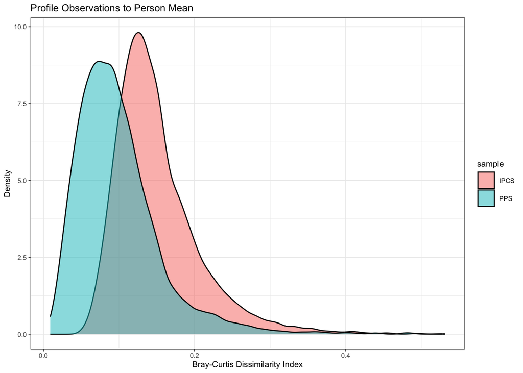

```r
load("~/Downloads/Projects/Trait Profiles IPCS Dataset/Data/prof_person_bray_ipcs.RData")

pps_obs <- prof_person_bray$bray
ipcs_obs <- prof_person_bray_ipcs$bray

prof_person_both_df <- data.frame(sample = c(rep("PPS", length(pps_obs)),
                              rep("IPCS", length(ipcs_obs))),
                 value=c(pps_obs, ipcs_obs))

profile_person_plot <- ggplot(prof_person_both_df, aes(x=value, fill=sample)) +
  geom_density(alpha = 0.5) +
  scale_colour_manual(values=c(gg_color_hue(2))) +
  ggtitle("Profile Observations to Person Mean") +
  xlab("Bray-Curtis Dissimilarity Index") +
  ylab("Density") +
  theme_bw(base_size = 8)

profile_person_plot
```

2. within profile-profile

```r
#so essentially, just bind rows the profile means within person and then bray curt that shit
pp_nested_profiles_multi <- pp_nested_profiles_multi %>%
  select(-Profiles) %>%
  group_by(SID) %>%
  summarize_all(~ list(c_across(profile_mean))) %>%
  mutate(profile_mean = map(profile_mean, unlist),
         profile_mean_df = map(profile_mean, function(x) matrix(x, byrow = TRUE, ncol = 15))) %>%
  ungroup() %>%
  select(SID, profile_mean_df)


#now bray curtis grouping by SID
pp_nested_profiles_multi <- pp_nested_profiles_multi %>%
  mutate(prof_to_prof = map(profile_mean_df, bray.part))

prof_prof <- map(pp_nested_profiles_multi$prof_to_prof, unlist) %>% unlist()
#organize into a df with three columns
prof_prof_within_df <- matrix(prof_prof, ncol = 3, byrow = TRUE) %>%
  as.data.frame() %>%
  rename(replacement = V1,
         nestedness = V2,
         bray = V3)

#what proportion is repl>nest
table(prof_prof_within_df$repl > prof_prof_within_df$nest)
```

```
FALSE  TRUE
   86    38
```

```r
38/124 #pps
```

```
[1] 0.3064516
```

```r
13/117 #ipcs
```

```
[1] 0.1111111
```

```r
51/241
```

```
[1] 0.2116183
```

```r
#sample descriptives
describe(prof_prof_within_df$bray) %>% select(mean, sd, median, min, max)
```

|  | mean | sd | median | min | max |
| --- | --- | --- | --- | --- | --- |
| X1 | 0.0692823 | 0.05734032 | 0.05630393 | 0 | 0.3585747 |

```r
describe(prof_prof_within_df$replacement) %>% select(mean, sd, median, min, max)
```

|  | mean | sd | median | min | max |
| --- | --- | --- | --- | --- | --- |
| X1 | 0.03190778 | 0.04120949 | 0.01801243 | 0 | 0.2423274 |

```r
describe(prof_prof_within_df$nestedness) %>% select(mean, sd, median, min, max)
```

|  | mean | sd | median | min | max |
| --- | --- | --- | --- | --- | --- |
| X1 | 0.05509106 | 0.05799854 | 0.03895714 | 0 | 0.368948 |

plot dist together

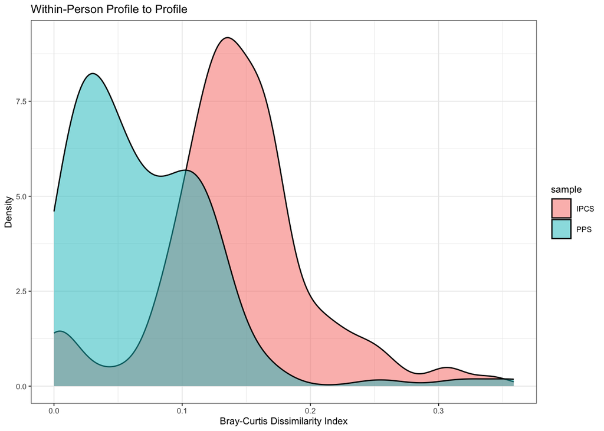

```r
#load ipcs
load("~/Downloads/Projects/Trait Profiles IPCS Dataset/Data/prof_prof_within_dist.RData")

#combine and label sample
prof_prof_within_dist_pp <- prof_prof_within_df$bray
prof_prof_within_dist_ipcs <-prof_prof_within_dist$bray


prof_prof_within_both_df <- data.frame(sample = c(rep("PPS", length(prof_prof_within_dist_pp)),
                              rep("IPCS", length(prof_prof_within_dist_ipcs))),
                 value=c(prof_prof_within_dist_pp, prof_prof_within_dist_ipcs))

profile_profile_within_plot <- ggplot(prof_prof_within_both_df, aes(x=value, fill=sample)) +
  geom_density(alpha = 0.5) +
  scale_colour_manual(values=c(gg_color_hue(2))) +
  ggtitle("Within-Person Profile to Profile") +
  xlab("Bray-Curtis Dissimilarity Index") +
  ylab("Density") +
  theme_bw(base_size = 8)

profile_profile_within_plot
```

## Typology

```r
#aggregate into traits for typology comps
trait_fun <- function(df){
  df %>%
    rowwise() %>%
    mutate(Extraversion = mean(c_across(Sociability:Assertive)),
           Agreeableness = mean(c_across(Trust:Compassion)),
           Conscientiousness = mean(c_across(Productivity:Organization)),
           Neuroticism_r = mean(c_across(Depression_r:EmotionalVol_r)),
           Openness = mean(c_across(IntCuriosity:CrtvImagination))
           ) %>%
    ungroup() %>%
    select(Extraversion:Openness)
}

pp_nested_traits <- pp_nested_profiles %>%
  mutate(trait_df = map(data, trait_fun),
         trait_mean = map(trait_df, colMeans),
         trait_mean = map(trait_mean, as.data.frame),
         trait_mean = map(trait_mean, t)) %>%
  select(SID, Profiles, trait_mean, trait_df) %>%
  mutate(trait_variance = map(trait_df, function(x) apply(x, 2, sd)))

#combine trait and typology vector and compute bray
pp_nested_traits_bcd <- pp_nested_traits %>%
  mutate(reserved_df = map2(reserved_list,
                            as.vector(pp_nested_traits$trait_mean),
                            function(x,y) rbind(x,y)),
         excitable_df = map2(excitable_list,
                            as.vector(pp_nested_traits$trait_mean),
                            function(x,y) rbind(x,y)),
         well_adj_df = map2(well_adj_list,
                            as.vector(pp_nested_traits$trait_mean),
                            function(x,y) rbind(x,y))) %>%
  mutate(res_dist = map(reserved_df, bray.part), #distance matrix
         well_dist = map(well_adj_df, bray.part),
         exc_dist = map(excitable_df, bray.part))
save(pp_nested_traits_bcd, file = "Data/pp_nested_traits_bcd.RData")
#extract estimates
typology_sample <- pp_nested_traits_bcd

#reserved estimates per profile
reserved_distance_vector <- list()
#so fucking stupid i had to for loop but map was killing me
for(i in 1:nrow(typology_sample)){
    reserved_distance_vector[[i]] <- typology_sample$res_dist[[i]]$bray #first col
}

#well adj estimates per profile
well_adj_distance_vector <- list()
#so fucking stupid i had to for loop but map was killing me
for(i in 1:nrow(typology_sample)){
    well_adj_distance_vector[[i]] <- typology_sample$well_dist[[i]]$bray #first col
}

#excitable
excitable_distance_vector <- list()
#so fucking stupid i had to for loop but map was killing me
for(i in 1:nrow(typology_sample)){
    excitable_distance_vector[[i]] <- typology_sample$exc_dist[[i]]$bray #first col
}

bray_typ_wide <- data.frame(
  SID = typology_sample$SID,
  Profiles = typology_sample$Profiles,
  Excitable = unlist(excitable_distance_vector),
  Reserved = unlist(reserved_distance_vector),
  WellAdj = unlist(well_adj_distance_vector)
  )
save(bray_typ_wide, file = "Data/bray_typ_wide.RData")

bray_typ <- bray_typ_wide %>%
  pivot_longer(cols = Excitable:WellAdj) %>%
  rename(mean = value,
         typology = name)
save(bray_typ, file = "Data/bray_typ.RData")

#overall bray
typology_bray_summary <- bray_typ %>%
  group_by(typology) %>%
  summarize(mean_distance = mean(mean, na.rm = TRUE),
            sd_distance = sd(mean, na.rm = TRUE))
typology_bray_summary
```

| typology | mean_distance | sd_distance |
| --- | --- | --- |
| Excitable | 0.15417110 | 0.03652289 |
| Reserved | 0.08636088 | 0.03770726 |
| WellAdj | 0.13576127 | 0.05433302 |

Replacement

```r
#extract first column
reserved_distance_vector <- list()
#so fucking stupid i had to for loop but map was killing me
for(i in 1:nrow(pp_nested_traits_bcd)){
    reserved_distance_vector[[i]] <- pp_nested_traits_bcd$res_dist[[i]]$bray.bal
}

reserved_distance_df <- map_dfr(reserved_distance_vector, describe)
reserved_distance_df <- cbind(pp_nested_traits_bcd$SID, pp_nested_traits_bcd$Profiles, reserved_distance_df) %>%
  rename(SID = "pp_nested_traits_bcd$SID",
         Profiles = "pp_nested_traits_bcd$Profiles") %>%
  select(SID, Profiles, mean, sd, median, min, max, se)

reserved_distance_df$typology <- "Reserved"

mean(reserved_distance_df$mean)
```

```
[1] 0.03419441
```

```r
min(reserved_distance_df$min)
```

```
[1] 0
```

```r
max(reserved_distance_df$max)
```

```
[1] 0.1005813
```

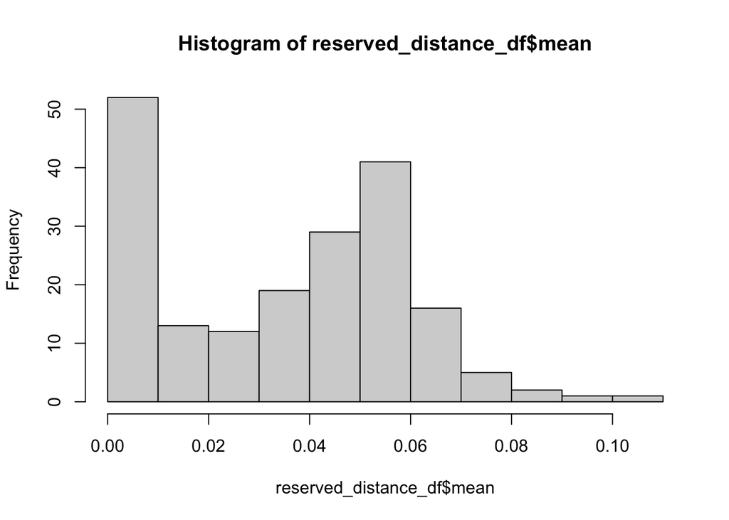

```r
hist(reserved_distance_df$mean)
```

```r
well_adj_distance_vector <- list()
#so fucking stupid i had to for loop but map was killing me
for(i in 1:nrow(pp_nested_traits_bcd)){
    well_adj_distance_vector[[i]] <- pp_nested_traits_bcd$well_dist[[i]]$bray.bal
}

well_adj_distance_df <- map_dfr(well_adj_distance_vector, describe)
well_adj_distance_df <- cbind(pp_nested_traits_bcd$SID, pp_nested_traits_bcd$Profiles, well_adj_distance_df) %>%
  rename(SID = "pp_nested_traits_bcd$SID",
         Profiles = "pp_nested_traits_bcd$Profiles") %>%
  select(SID, Profiles, mean, sd, median, min, max, se)

well_adj_distance_df$typology <- "Well-Adjusted"


mean(well_adj_distance_df$mean)
```

```
[1] 0.006302034
```

```r
min(well_adj_distance_df$min)
```

```
[1] 0
```

```r
max(well_adj_distance_df$max)
```

```
[1] 0.08009621
```

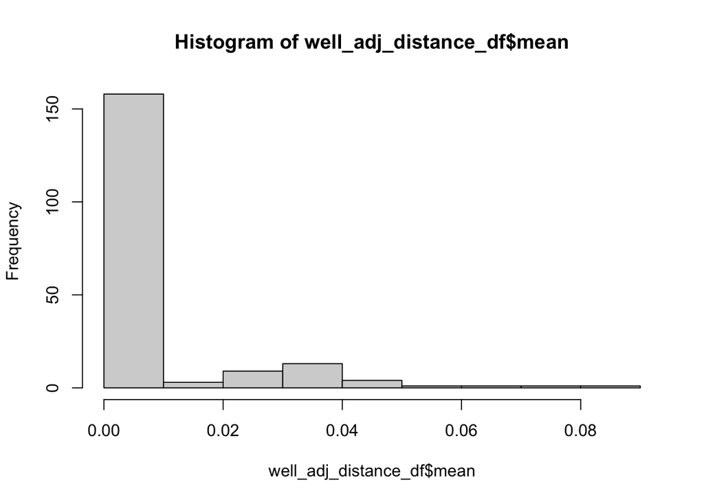

```r
hist(well_adj_distance_df$mean)
```

```r
excitable_distance_vector <- list()
#so fucking stupid i had to for loop but map was killing me
for(i in 1:nrow(pp_nested_traits_bcd)){
    excitable_distance_vector[[i]] <- pp_nested_traits_bcd$exc_dist[[i]]$bray.bal
}

excitable_distance_df <- map_dfr(excitable_distance_vector, describe)
excitable_distance_df <- cbind(pp_nested_traits_bcd$SID, pp_nested_traits_bcd$Profiles, excitable_distance_df) %>%
  rename(SID = "pp_nested_traits_bcd$SID",
         Profiles = "pp_nested_traits_bcd$Profiles") %>%
  select(SID, Profiles, mean, sd, median, min, max, se)

excitable_distance_df$typology <- "Excitable"

mean(excitable_distance_df$mean)
```

```
[1] 0.0713247
```

```r
min(excitable_distance_df$min)
```

```
[1] 0
```

```r
max(excitable_distance_df$max)
```

```
[1] 0.1730998
```

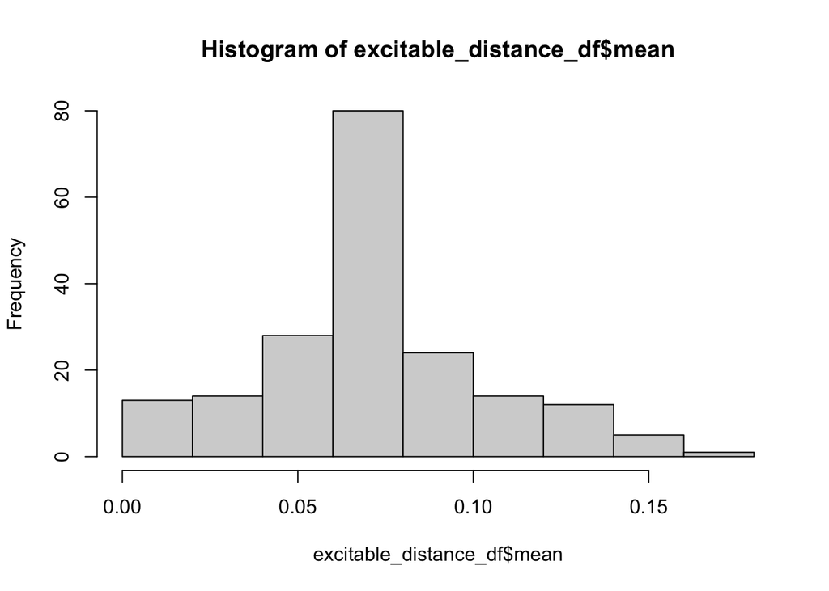

```r
hist(excitable_distance_df$mean)
```

```r
bray_typ <- bind_rows(excitable_distance_df, reserved_distance_df, well_adj_distance_df)

#overall bray
typology_repl_summary <- bray_typ %>%
  group_by(typology) %>%
  summarize(mean_repl = mean(mean, na.rm = TRUE),
            sd_repl = sd(mean, na.rm = TRUE))
```

Nestedness

```r
#extract first column
reserved_distance_vector <- list()
#so fucking stupid i had to for loop but map was killing me
for(i in 1:nrow(pp_nested_traits_bcd)){
    reserved_distance_vector[[i]] <- pp_nested_traits_bcd$res_dist[[i]]$bray.gra
}

reserved_distance_df <- map_dfr(reserved_distance_vector, describe)
reserved_distance_df <- cbind(pp_nested_traits_bcd$SID, pp_nested_traits_bcd$Profiles, reserved_distance_df) %>%
  rename(SID = "pp_nested_traits_bcd$SID",
         Profiles = "pp_nested_traits_bcd$Profiles") %>%
  select(SID, Profiles, mean, sd, median, min, max, se)

reserved_distance_df$typology <- "Reserved"

mean(reserved_distance_df$mean)
```

```
[1] 0.05216648
```

```r
min(reserved_distance_df$min) #
```

```
[1] 0.0005330799
```

```r
max(reserved_distance_df$max) #
```

```
[1] 0.2810273
```

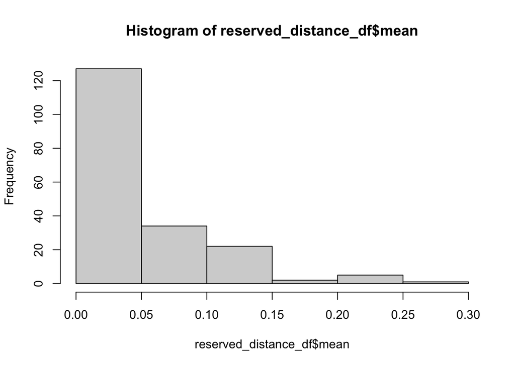

```r
hist(reserved_distance_df$mean)
```

```r
well_adj_distance_vector <- list()
#so fucking stupid i had to for loop but map was killing me
for(i in 1:nrow(pp_nested_traits_bcd)){
    well_adj_distance_vector[[i]] <- pp_nested_traits_bcd$well_dist[[i]]$bray.gra
}

well_adj_distance_df <- map_dfr(well_adj_distance_vector, describe)
well_adj_distance_df <- cbind(pp_nested_traits_bcd$SID, pp_nested_traits_bcd$Profiles, well_adj_distance_df) %>%
  rename(SID = "pp_nested_traits_bcd$SID",
         Profiles = "pp_nested_traits_bcd$Profiles") %>%
  select(SID, Profiles, mean, sd, median, min, max, se)

well_adj_distance_df$typology <- "Well-Adjusted"


mean(well_adj_distance_df$mean)
```

```
[1] 0.1294592
```

```r
min(well_adj_distance_df$min) #.
```

```
[1] 0.002299116
```

```r
max(well_adj_distance_df$max) #.
```

```
[1] 0.3709946
```

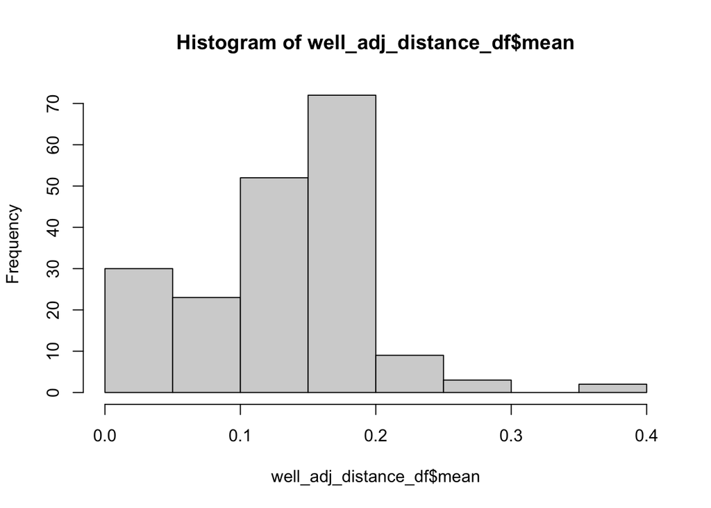

```r
hist(well_adj_distance_df$mean)
```

```r
excitable_distance_vector <- list()
#so fucking stupid i had to for loop but map was killing me
for(i in 1:nrow(pp_nested_traits_bcd)){
    excitable_distance_vector[[i]] <- pp_nested_traits_bcd$exc_dist[[i]]$bray.gra
}

excitable_distance_df <- map_dfr(excitable_distance_vector, describe)
excitable_distance_df <- cbind(pp_nested_traits_bcd$SID, pp_nested_traits_bcd$Profiles, excitable_distance_df) %>%
  rename(SID = "pp_nested_traits_bcd$SID",
         Profiles = "pp_nested_traits_bcd$Profiles") %>%
  select(SID, Profiles, mean, sd, median, min, max, se)

excitable_distance_df$typology <- "Excitable"

mean(excitable_distance_df$mean)
```

```
[1] 0.0828464
```

```r
min(excitable_distance_df$min)
```

```
[1] 0.00271669
```

```r
max(excitable_distance_df$max)
```

```
[1] 0.3236655
```

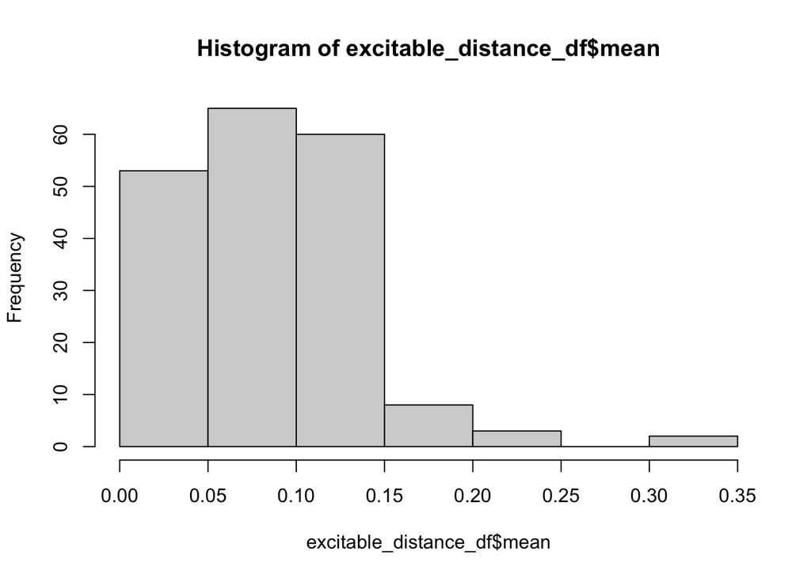

```r
hist(excitable_distance_df$mean)
```

```r
bray_typ <- bind_rows(excitable_distance_df, reserved_distance_df, well_adj_distance_df)

#overall bray
typology_nest_summary <- bray_typ %>%
  group_by(typology) %>%
  summarize(mean_nest = mean(mean, na.rm = TRUE),
            sd_nest = sd(mean, na.rm = TRUE))
```

```r
fuck <- left_join(typology_bray_summary, typology_repl_summary)
fuck <- left_join(fuck, typology_nest_summary)
```

Table

```r
load("~/Downloads/Projects/Trait Profiles IPCS Dataset/Data/ipcs_typology_dist.RData")
#pps + ipcs
typo_df <- rbind(ipcs_typology_dist, fuck)
colnames(typo_df) <- c("Typology", "Overall Mean", "Overall SD", "Repl. Mean", "Repl. SD", "Nest Mean", "Nest SD")

typo_df[,2:7] <- round(typo_df[,2:7], 2)


#shorten to well adj
typo_df[,1] <- rep(c("Excitable", "Reserved", "Well-Adj"), 2)

kable(typo_df, escape = F, align = c("r", rep("c",3), "l"),
        caption = "<strong> Sample-Level Typology Bray-Curtis Dissimilarities </strong>") %>%
    kable_classic(full_width = F, html_font = "Times") %>%
  pack_rows("IPCS",1, 3) %>%
  pack_rows("PPS", 4, 6)
```

**Sample-Level Typology Bray-Curtis Dissimilarities**

| Typology | Overall Mean | Overall SD | Repl. Mean | Repl. SD | Nest Mean | Nest SD |
| --- | --- | --- | --- | --- | --- | --- |
| **IPCS** |  |  |  |  |  |  |
| Excitable | 0.14 | 0.04 | 0.06 | 0.04 | 0.07 | 0.05 |
| Reserved | 0.11 | 0.05 | 0.02 | 0.02 | 0.09 | 0.06 |
| Well-Adj | 0.10 | 0.06 | NA | NA | NA | NA |
| **PPS** |  |  |  |  |  |  |
| Excitable | 0.15 | 0.04 | 0.07 | 0.03 | 0.08 | 0.05 |
| Reserved | 0.09 | 0.04 | 0.03 | 0.03 | 0.05 | 0.05 |
| Well-Adj | 0.14 | 0.05 | NA | NA | NA | NA |

Inter-Typology Comp

```r
typology_values_df <- rbind(excitable_vec, reserved_vec, well_adj_vec)
bray.part(typology_values_df)
```

```
$bray.bal
             excitable_vec reserved_vec
reserved_vec    0.04545455
well_adj_vec    0.01601281   0.00000000

$bray.gra
             excitable_vec reserved_vec
reserved_vec    0.07992506
well_adj_vec    0.05292658   0.13690233

$bray
             excitable_vec reserved_vec
reserved_vec    0.12537961
well_adj_vec    0.06893939   0.13690233
```

Exemplars

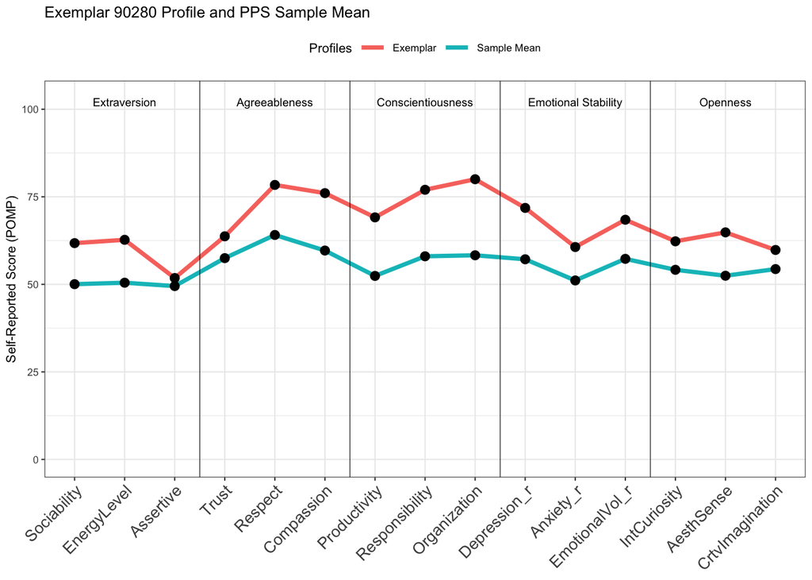

```r
prof_to_sample_ex <- mc %>% filter(SID == 90280) %>%
  select(Sociability:CrtvImagination) %>%
  t() %>%
  as.data.frame()

prof_to_sample_ex$facet <- rownames(prof_to_sample_ex)
prof_to_sample_ex$facet <- factor(prof_to_sample_ex$facet, levels = c("Sociability", "EnergyLevel", "Assertive", "Trust", "Respect", "Compassion", "Productivity", "Responsibility", "Organization", "Depression_r", "Anxiety_r", "EmotionalVol_r", "IntCuriosity", "AesthSense", "CrtvImagination"))
prof_to_sample_ex <- bind_rows(pp_sample_mean_plot, prof_to_sample_ex %>% rename(value = V1) %>% mutate(Profiles = "Exemplar"))


prof_to_sample_ex %>%
    ggplot(aes(x = facet, y = value, group = Profiles, color = Profiles)) +
    geom_line(linewidth = 1.25) +
    geom_point(size = 2.25, color = "black") +
    labs(x = NULL, y = "Self-Reported Score (POMP)") +
    ylim(0,103) +
    theme_bw(base_size = 8) +
    theme(axis.text.x = element_text(angle = 45, hjust = 1, size = 10), legend.position = "top") +
    labs(title = "Exemplar 90280 Profile and PPS Sample Mean") +
    #annotate("rect", xmin = 3.8, xmax = 6.2, ymin = 46, ymax = 93, fill = "green", alpha = .2) +
    #annotate("rect", xmin = 0.8, xmax = 3.2, ymin = 25, ymax = 77, fill = "red", alpha = .2) +
    geom_vline(xintercept = c(3.5, 6.5, 9.5, 12.5), size = 0.25, alpha = 0.8) +
    annotate("text", x = 2, y = 102, size = 2.5,label = "Extraversion") +
    annotate("text", x = 5, y = 102, size = 2.5,label = "Agreeableness") +
    annotate("text", x = 8, y = 102, size=  2.5, label = "Conscientiousness") +
    annotate("text", x = 11, y = 102, size = 2.5, label = "Emotional Stability") +
    annotate("text", x = 14, y = 102, size = 2.5, label = "Openness")
```

```r
#profile_sample
prof_sample_ex <- prof_sample_bray[["bray"]][166] #position 166 in pp_nested_profiels

#profile_profile
#so there 191 profiles; we want just the exemplars (position 166) so

z <- (prof_prof_bray$bray)
v <- as.matrix(z)
x <- v[166,]
x <- x[-166]
mean(v[166,])
```

```
[1] 0.1244166
```

```r
sd(v[166,])
```

```
[1] 0.05201259
```

```r
tail(sort(x), 10)
```

```
      152        85        19         6       153       118        74         7
0.1960165 0.2114846 0.2136344 0.2148387 0.2382416 0.2607973 0.2669267 0.2768972
      183       110
0.3555759 0.3589428
```

Plot em fuckin all together

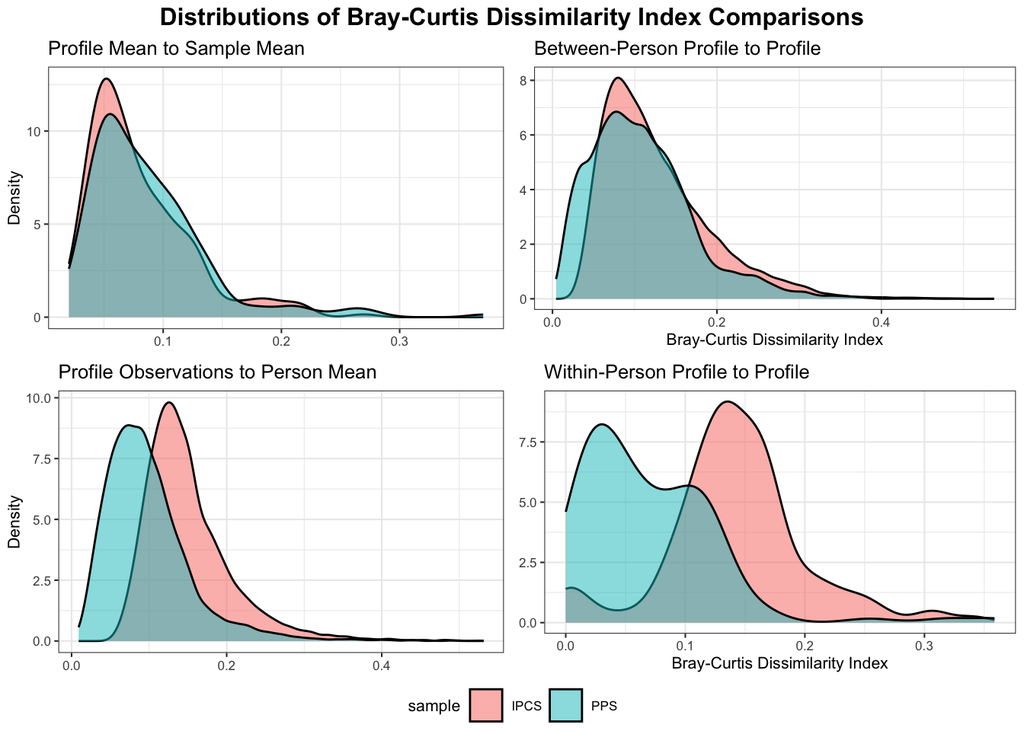

```r
library(ggpubr)
all_four_dist_plot <- ggarrange(
  prof_sample_dist_plot + rremove("xlab"),
  prof_prof_btwn_plot + rremove("ylab"),
  profile_person_plot + rremove("xlab"),
  profile_profile_within_plot + rremove("ylab"),
  common.legend = TRUE, legend = "bottom",
  ncol = 2, nrow = 2
)

all_four_dist_plot <- annotate_figure(all_four_dist_plot,
                top = text_grob("Distributions of Bray-Curtis Dissimilarity Index Comparisons",
                  face = "bold"))

all_four_dist_plot
```

```r
pdf("z.Plots/Profile Comparisons/All Bray Curtis Comparisons.pdf")
print(all_four_dist_plot)
dev.off()
```

save

```r
save(pp_nested_traits_bcd, file = "Data/pp_nested_traits_bcd.RData")
```